# Problem Set 4

Statistics and Econometrics

Konstantinos Paganopoulos

25 November 2019

## Question 1

> Use the data set nbasal.RData to answer this question. A regression model is needed to study the factors that influence salaries of NBA players. We use $log(wage)$ as the dependent variable. Potential factors that will affect a player’s wage include experience ($exper$, $coll$), games’ participation ($games$, $avgmin$), position ($forward$, $center$, $guard$), performance ($points$, $rebounds$, $assists$), prestige ($draft$, $allstar$), and demographic factors ($black$, $children$, $marr$). For this question, it is fine if you only consider these variables in the level form.
> 1. Identify if there is any multicollinearity problem.

We first load the dataset.

```r
load("nbasal.RData")
desc
```

| variable | label |
| --- | --- |
| marr | =1 if married |
| wage | annual salary, thousands $ |
| exper | years as professional player |
| age | age in years |
| coll | years played in college |
| games | average games per year |
| minutes | average minutes per year |
| guard | =1 if guard |
| forward | =1 if forward |
| center | =1 if center |

[output cut: 12 more lines]

We rename the data frame with a more informative name.

```r
nbasal.data <- data
```

We estimate the following regression model.

```r
lwage.m1 <- lm(log(wage) ~ exper + coll + games + avgmin + forward + center + guard + points + rebounds + assists + draft + allstar + black + children + marr , data = nbasal.data)
summary(lwage.m1)
```

```
##
## Call:
## lm(formula = log(wage) ~ exper + coll + games + avgmin + forward +
##     center + guard + points + rebounds + assists + draft + allstar +
##     black + children + marr, data = nbasal.data)
##
## Residuals:
##     Min      1Q  Median      3Q     Max
## -2.2454 -0.2266  0.1055  0.3311  1.5364
##
## Coefficients: (1 not defined because of singularities)
##              Estimate Std. Error t value Pr(>|t|)
## (Intercept)  5.988479   0.292672  20.461  < 2e-16 ***
## exper        0.065266   0.011820   5.522 9.23e-08 ***
## coll        -0.048013   0.053886  -0.891  0.37387
## games       -0.001355   0.002605  -0.520  0.60349
## avgmin       0.017842   0.012800   1.394  0.16471
## forward      0.178025   0.118892   1.497  0.13570
## center       0.209857   0.150327   1.396  0.16409
## guard              NA         NA      NA       NA
## points       0.046744   0.016187   2.888  0.00426 **
## rebounds     0.001990   0.025144   0.079  0.93699
## assists      0.029880   0.031388   0.952  0.34215
## draft       -0.010425   0.002153  -4.841 2.40e-06 ***
## allstar     -0.294134   0.151925  -1.936  0.05411 .
## black        0.136278   0.098071   1.390  0.16603
## children     0.040598   0.083551   0.486  0.62750
## marr        -0.030959   0.083749  -0.370  0.71198
## ---
## Signif. codes:  0 '***' 0.001 '**' 0.01 '*' 0.05 '.' 0.1 ' ' 1
##
## Residual standard error: 0.5727 on 225 degrees of freedom
##   (29 observations deleted due to missingness)
## Multiple R-squared:  0.529,  Adjusted R-squared:  0.4997
## F-statistic: 18.05 on 14 and 225 DF,  p-value: < 2.2e-16
```

```r
stargazer(lwage.m1, type = "html")
```

|  | *Dependent variable:* |
| --- | --- |
|  | log(wage) |
| exper | 0.065*** |
|  | (0.012) |
| coll | -0.048 |
|  | (0.054) |
| games | -0.001 |
|  | (0.003) |
| avgmin | 0.018 |
|  | (0.013) |
| forward | 0.178 |
|  | (0.119) |
| center | 0.210 |
|  | (0.150) |
| guard |  |
| points | 0.047*** |
|  | (0.016) |
| rebounds | 0.002 |
|  | (0.025) |
| assists | 0.030 |
|  | (0.031) |
| draft | -0.010*** |
|  | (0.002) |
| allstar | -0.294* |
|  | (0.152) |
| black | 0.136 |
|  | (0.098) |
| children | 0.041 |
|  | (0.084) |
| marr | -0.031 |
|  | (0.084) |
| Constant | 5.988*** |
|  | (0.293) |
| Observations | 240 |
| R<sup>2</sup> | 0.529 |
| Adjusted R<sup>2</sup> | 0.500 |
| Residual Std. Error | 0.573 (df = 225) |
| F Statistic | 18.048*** (df = 14; 225) |
| *Note:* | p<0.1; p<0.05; p<0.01 |

We exclude one of the dummy variables of the above model (we randomly select $guard$) and we have the following model:

```r
lwage.mod <- lm(log(wage) ~ exper + coll + games + avgmin + forward + center + points + rebounds + assists + draft + allstar + black + children + marr , data = nbasal.data)
summary(lwage.mod)
```

```
##
## Call:
## lm(formula = log(wage) ~ exper + coll + games + avgmin + forward +
##     center + points + rebounds + assists + draft + allstar +
##     black + children + marr, data = nbasal.data)
##
## Residuals:
##     Min      1Q  Median      3Q     Max
## -2.2454 -0.2266  0.1055  0.3311  1.5364
##
## Coefficients:
##              Estimate Std. Error t value Pr(>|t|)
## (Intercept)  5.988479   0.292672  20.461  < 2e-16 ***
## exper        0.065266   0.011820   5.522 9.23e-08 ***
## coll        -0.048013   0.053886  -0.891  0.37387
## games       -0.001355   0.002605  -0.520  0.60349
## avgmin       0.017842   0.012800   1.394  0.16471
## forward      0.178025   0.118892   1.497  0.13570
## center       0.209857   0.150327   1.396  0.16409
## points       0.046744   0.016187   2.888  0.00426 **
## rebounds     0.001990   0.025144   0.079  0.93699
## assists      0.029880   0.031388   0.952  0.34215
## draft       -0.010425   0.002153  -4.841 2.40e-06 ***
## allstar     -0.294134   0.151925  -1.936  0.05411 .
## black        0.136278   0.098071   1.390  0.16603
## children     0.040598   0.083551   0.486  0.62750
## marr        -0.030959   0.083749  -0.370  0.71198
## ---
## Signif. codes:  0 '***' 0.001 '**' 0.01 '*' 0.05 '.' 0.1 ' ' 1
##
## Residual standard error: 0.5727 on 225 degrees of freedom
##   (29 observations deleted due to missingness)
## Multiple R-squared:  0.529,  Adjusted R-squared:  0.4997
## F-statistic: 18.05 on 14 and 225 DF,  p-value: < 2.2e-16
```

```r
stargazer(lwage.mod, type = "html")
```

|  | *Dependent variable:* |
| --- | --- |
|  | log(wage) |
| exper | 0.065*** |
|  | (0.012) |
| coll | -0.048 |
|  | (0.054) |
| games | -0.001 |
|  | (0.003) |
| avgmin | 0.018 |
|  | (0.013) |
| forward | 0.178 |
|  | (0.119) |
| center | 0.210 |
|  | (0.150) |
| points | 0.047*** |
|  | (0.016) |
| rebounds | 0.002 |
|  | (0.025) |
| assists | 0.030 |
|  | (0.031) |
| draft | -0.010*** |
|  | (0.002) |
| allstar | -0.294* |
|  | (0.152) |
| black | 0.136 |
|  | (0.098) |
| children | 0.041 |
|  | (0.084) |
| marr | -0.031 |
|  | (0.084) |
| Constant | 5.988*** |
|  | (0.293) |
| Observations | 240 |
| R<sup>2</sup> | 0.529 |
| Adjusted R<sup>2</sup> | 0.500 |
| Residual Std. Error | 0.573 (df = 225) |
| F Statistic | 18.048*** (df = 14; 225) |
| *Note:* | p<0.1; p<0.05; p<0.01 |

We now calculate the $VIF$ for the above model:

```r
vif(lwage.mod)
```

```
##     exper      coll     games    avgmin   forward    center    points
##  1.210240  1.082791  1.489404 10.531976  2.491042  2.432065  6.517269
##  rebounds   assists     draft   allstar     black  children      marr
##  4.023917  3.243874  1.186138  1.899916  1.108414  1.162197  1.268137
```

From the above results we see that the only variable that has a $VIF$ greater than 10 is $avgmin$.

As a result, there is a multicollinearity problem for the $avgmin$ variable.

> 2. Find the model(s) with the lowest AIC by using forward and backward-stepwise selections.

We first omit the N/A values from the data set.

```r
data.new <- na.omit(nbasal.data)
```

We then try to find the model with the lowest AIC using forward and backward-stepwise selections.

```r
lwage2.null <- lm(log(wage) ~ 1, data.new)
lwage2.full <- lm(log(wage) ~ exper + coll + games + avgmin + forward + center + guard + points + rebounds + assists + draft + allstar + black + children + marr, data.new)
step(lwage2.null, scope = list(lower = lwage2.null, upper = lwage2.full),
direction = "forward")
```

```
## Start:  AIC=-100.38
## log(wage) ~ 1
##
##            Df Sum of Sq    RSS      AIC
## + avgmin    1    55.990 100.67 -204.511
## + points    1    55.720 100.94 -203.868
## + rebounds  1    32.444 124.22 -154.069
## + draft     1    25.310 131.35 -140.667
## + exper     1    20.319 136.34 -131.716
## + assists   1    14.797 141.86 -122.188
## + games     1    14.474 142.19 -121.642
## + allstar   1    12.789 143.87 -118.814
## + children  1     5.925 150.73 -107.629
## + marr      1     3.002 153.66 -103.019
## + black     1     2.955 153.70 -102.946
## + coll      1     2.259 154.40 -101.861
## + forward   1     1.630 155.03 -100.886
## <none>                  156.66 -100.376
## + guard     1     0.767 155.89  -99.554
## + center    1     0.258 156.40  -98.771
##
## Step:  AIC=-204.51
## log(wage) ~ avgmin
##
##            Df Sum of Sq     RSS     AIC
## + exper     1   10.4464  90.223 -228.81
## + draft     1    9.8787  90.791 -227.30
## + points    1    3.6087  97.061 -211.27
## + guard     1    3.0656  97.604 -209.93
## + rebounds  1    1.6734  98.996 -206.53
## + center    1    1.2541  99.415 -205.52
## <none>                  100.669 -204.51
## + children  1    0.8257  99.844 -204.49
## + marr      1    0.8134  99.856 -204.46
## + forward   1    0.7985  99.871 -204.42
## + assists   1    0.7802  99.889 -204.38
## + coll      1    0.5629 100.107 -203.86
## + black     1    0.3431 100.326 -203.33
## + games     1    0.1427 100.527 -202.85
## + allstar   1    0.0328 100.637 -202.59
```

[output cut: 70 more lines]

```
##
## Step:  AIC=-264.69
## log(wage) ~ avgmin + exper + draft + points + guard + allstar
##
##            Df Sum of Sq    RSS     AIC
## <none>                  75.145 -264.69
## + black     1   0.42971 74.715 -264.07
## + coll      1   0.27910 74.866 -263.59
## + assists   1   0.26068 74.884 -263.53
## + games     1   0.10501 75.040 -263.03
## + children  1   0.08671 75.058 -262.97
## + marr      1   0.02013 75.125 -262.76
## + forward   1   0.01376 75.131 -262.74
## + center    1   0.01376 75.131 -262.74
## + rebounds  1   0.00041 75.145 -262.69
```

```
##
## Call:
## lm(formula = log(wage) ~ avgmin + exper + draft + points + guard +
##     allstar, data = data.new)
##
## Coefficients:
## (Intercept)       avgmin        exper        draft       points
##     5.99388      0.02263      0.06457     -0.01068      0.04368
##       guard      allstar
##    -0.13365     -0.24198
```

Hence the model with the lowest AIC using the forward selection is the:  
$log(wage)$ ~ $avgmin$ $+$ $exper$ $+$ $draft$ $+$ $points$ $+$ $guard$ $+$ $allstar$ with $AIC = -264.69$.

```r
step(lwage2.full, direction = "backward")
```

```
## Start:  AIC=-253.06
## log(wage) ~ exper + coll + games + avgmin + forward + center +
##     guard + points + rebounds + assists + draft + allstar + black +
##     children + marr
##
##
## Step:  AIC=-253.06
## log(wage) ~ exper + coll + games + avgmin + forward + center +
##     points + rebounds + assists + draft + allstar + black + children +
##     marr
##
##            Df Sum of Sq    RSS     AIC
## - rebounds  1    0.0021 73.793 -255.05
## - marr      1    0.0448 73.836 -254.91
## - children  1    0.0774 73.868 -254.81
## - games     1    0.0887 73.880 -254.77
## - coll      1    0.2604 74.051 -254.21
## - assists   1    0.2972 74.088 -254.09
## <none>                  73.791 -253.06
## - black     1    0.6333 74.424 -253.01
## - avgmin    1    0.6373 74.428 -252.99
## - center    1    0.6391 74.430 -252.99
## - forward   1    0.7353 74.526 -252.68
## - allstar   1    1.2293 75.020 -251.09
## - points    1    2.7349 76.526 -246.32
## - draft     1    7.6872 81.478 -231.27
## - exper     1    9.9987 83.790 -224.56
##
## Step:  AIC=-255.05
## log(wage) ~ exper + coll + games + avgmin + forward + center +
##     points + assists + draft + allstar + black + children + marr
##
##            Df Sum of Sq    RSS     AIC
## - marr      1    0.0488 73.842 -256.89
## - children  1    0.0802 73.873 -256.79
## - games     1    0.0885 73.882 -256.76
## - coll      1    0.2667 74.060 -256.18
## - assists   1    0.3117 74.105 -256.04
## <none>                  73.793 -255.05
## - black     1    0.6385 74.432 -254.98
```

[output cut: 114 more lines]

```
## - avgmin   1    2.0896 77.839 -258.24
## - points   1    2.6549 78.404 -256.50
## - draft    1    8.8400 84.589 -238.28
## - exper    1   12.0165 87.766 -229.43
##
## Step:  AIC=-263.57
## log(wage) ~ exper + avgmin + points + draft + allstar
##
##           Df Sum of Sq    RSS     AIC
## <none>                 76.128 -263.57
## - allstar  1    0.8775 77.005 -262.82
## - avgmin   1    2.2685 78.396 -258.53
## - points   1    2.5107 78.638 -257.79
## - draft    1    9.6892 85.817 -236.82
## - exper    1   11.9576 88.085 -230.56
```

```
##
## Call:
## lm(formula = log(wage) ~ exper + avgmin + points + draft + allstar,
##     data = data.new)
##
## Coefficients:
## (Intercept)        exper       avgmin       points        draft
##     5.97554      0.06612      0.02197      0.04227     -0.01141
##     allstar
##    -0.23426
```

Hence the model with the lowest AIC using the backward-stepwise selection is the:  
$log(wage)$ ~ $exper$ $+$ $avgmin$ $+$ $points$ $+$ $draft$ $+$ $allstar$ with $AIC = -263.57$.

From the above results we can conclude that the model with the lowest AIC value is the following:  
$log(wage)$ ~ $avgmin$ $+$ $exper$ $+$ $draft$ $+$ $points$ $+$ $guard$ $+$ $allstar$ with $AIC = -264.69$.

> 3. Plot residuals against fitted values of model(s) from part 2. Is the residual plot satisfactory? Comment.

We plot the reiduals against fitted values of the best moded (that one with lowest $AIC$ values) of Question 1.2:

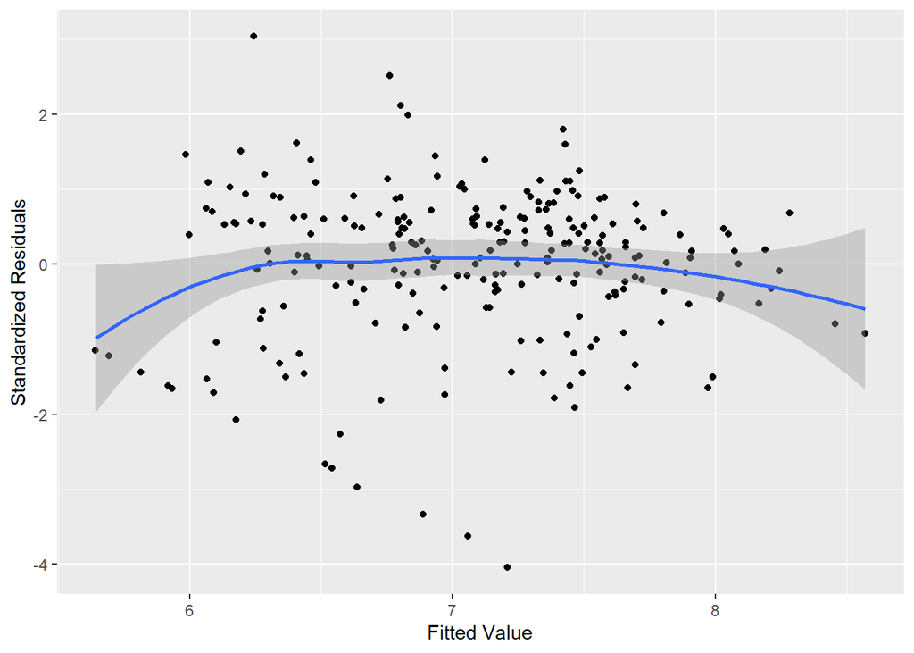

```r
bestmodel <- lm(log(wage) ~ avgmin + exper + draft + points + guard + allstar, data = nbasal.data)

ggplot(bestmodel, aes(.fitted, .stdresid)) + geom_point() + stat_smooth(method = "loess") + xlab("Fitted Value") + ylab("Standardized Residuals")
```

> 4. Repeat part 2 without $avgmin$. Comment on the differences.

We try again to find the model with the lowest AIC using forward and backward-stepwise selections, but this time we do not include the variable $avgmin$ in our model.

```r
lwage3.null <- lm(log(wage) ~ 1, data.new)
lwage3.full <- lm(log(wage) ~ exper + coll + games + forward + center + guard + points + rebounds + assists + draft + allstar + black + children + marr, data.new)
step(lwage3.null, scope = list(lower = lwage3.null, upper = lwage3.full),
direction = "forward")
```

```
## Start:  AIC=-100.38
## log(wage) ~ 1
##
##            Df Sum of Sq    RSS      AIC
## + points    1    55.720 100.94 -203.868
## + rebounds  1    32.444 124.22 -154.069
## + draft     1    25.310 131.35 -140.667
## + exper     1    20.319 136.34 -131.716
## + assists   1    14.797 141.86 -122.188
## + games     1    14.474 142.19 -121.642
## + allstar   1    12.789 143.87 -118.814
## + children  1     5.925 150.73 -107.629
## + marr      1     3.002 153.66 -103.019
## + black     1     2.955 153.70 -102.946
## + coll      1     2.259 154.40 -101.861
## + forward   1     1.630 155.03 -100.886
## <none>                  156.66 -100.376
## + guard     1     0.767 155.89  -99.554
## + center    1     0.258 156.40  -98.771
##
## Step:  AIC=-203.87
## log(wage) ~ points
##
##            Df Sum of Sq     RSS     AIC
## + exper     1   11.6973  89.242 -231.43
## + draft     1    7.5887  93.351 -220.62
## + rebounds  1    3.8058  97.134 -211.09
## + guard     1    2.7406  98.199 -208.47
## + allstar   1    1.6628  99.277 -205.85
## + forward   1    1.4261  99.514 -205.28
## + children  1    1.1442  99.796 -204.60
## <none>                  100.940 -203.87
## + black     1    0.7152 100.224 -203.57
## + marr      1    0.6425 100.297 -203.40
## + center    1    0.3544 100.585 -202.71
## + games     1    0.1543 100.785 -202.24
## + coll      1    0.1085 100.831 -202.13
## + assists   1    0.0189 100.921 -201.91
##
## Step:  AIC=-231.43
```

[output cut: 63 more lines]

```
## + games     1   0.00000 76.886 -259.19
##
## Step:  AIC=-262.06
## log(wage) ~ points + exper + draft + allstar + rebounds + assists
##
##            Df Sum of Sq    RSS     AIC
## <none>                  75.975 -262.06
## + guard     1   0.55192 75.423 -261.81
## + black     1   0.51929 75.456 -261.70
## + forward   1   0.25201 75.723 -260.85
## + coll      1   0.17252 75.802 -260.60
## + children  1   0.04555 75.929 -260.20
## + games     1   0.02002 75.955 -260.12
## + marr      1   0.00796 75.967 -260.08
## + center    1   0.00551 75.969 -260.07
```

```
##
## Call:
## lm(formula = log(wage) ~ points + exper + draft + allstar + rebounds +
##     assists, data = data.new)
##
## Coefficients:
## (Intercept)       points        exper        draft      allstar
##     6.06382      0.05895      0.06558     -0.01082     -0.32471
##    rebounds      assists
##     0.04178      0.03621
```

Hence the model with the lowest AIC using the forward selection is the:  
$log(wage)$ ~ $points$ $+$ $exper$ $+$ $draft$ $+$ $allstar$ $+$ $rebounds$ $+$ $assists$ with $AIC = -262.06$.

```r
step(lwage3.full, direction = "backward")
```

```
## Start:  AIC=-252.99
## log(wage) ~ exper + coll + games + forward + center + guard +
##     points + rebounds + assists + draft + allstar + black + children +
##     marr
##
##
## Step:  AIC=-252.99
## log(wage) ~ exper + coll + games + forward + center + points +
##     rebounds + assists + draft + allstar + black + children +
##     marr
##
##            Df Sum of Sq    RSS     AIC
## - games     1    0.0142 74.442 -254.95
## - marr      1    0.0397 74.468 -254.87
## - children  1    0.0630 74.491 -254.79
## - coll      1    0.1663 74.595 -254.46
## - rebounds  1    0.3893 74.818 -253.74
## - center    1    0.4659 74.894 -253.50
## <none>                  74.428 -252.99
## - forward   1    0.6721 75.100 -252.84
## - black     1    0.7490 75.177 -252.59
## - assists   1    1.5225 75.951 -250.13
## - allstar   1    1.9974 76.426 -248.64
## - draft     1    7.5278 81.956 -231.87
## - points    1    9.7844 84.213 -225.35
## - exper     1   10.1399 84.568 -224.34
##
## Step:  AIC=-254.95
## log(wage) ~ exper + coll + forward + center + points + rebounds +
##     assists + draft + allstar + black + children + marr
##
##            Df Sum of Sq    RSS     AIC
## - marr      1    0.0404 74.483 -256.82
## - children  1    0.0630 74.505 -256.74
## - coll      1    0.1672 74.610 -256.41
## - rebounds  1    0.3752 74.818 -255.74
## - center    1    0.5048 74.947 -255.32
## <none>                  74.442 -254.95
## - forward   1    0.6827 75.125 -254.76
## - black     1    0.7422 75.185 -254.57
```

[output cut: 56 more lines]

```
##
## Step:  AIC=-260.72
## log(wage) ~ exper + forward + center + points + assists + draft +
##     allstar + black
##
##           Df Sum of Sq    RSS     AIC
## <none>                 75.136 -260.72
## - black    1    0.9255 76.061 -259.78
## - center   1    1.5483 76.684 -257.83
## - assists  1    1.7495 76.885 -257.20
## - forward  1    2.1241 77.260 -256.03
## - allstar  1    2.2421 77.378 -255.66
## - draft    1    7.9033 83.039 -238.72
## - exper    1   11.1423 86.278 -229.53
## - points   1   18.8789 94.015 -208.93
```

```
##
## Call:
## lm(formula = log(wage) ~ exper + forward + center + points +
##     assists + draft + allstar + black, data = data.new)
##
## Coefficients:
## (Intercept)        exper      forward       center       points
##     5.81184      0.06446      0.24882      0.27297      0.06968
##     assists        draft      allstar        black
##     0.05805     -0.01053     -0.37251      0.16136
```

Hence the model with the lowest AIC using the backward-stepwise selection is the:  
$log(wage)$ ~ $exper$ $+$ $forward$ $+$ $center$ $+$ $points$ $+$ $assists$ $+$ $draft$ $+$ $allstar$ $+$ $black$ with $AIC = -260.72$.

From the above results we can conclude that the model with the lowest AIC value is the following:  
$log(wage)$ ~ $points + exper + draft + allstar + rebounds + assists$ with $AIC = -262.06$.

## Question 2

> Use the data set meap93.RData to answer this question. Let $math10$ denote the percentage of students at a Michigan high school receiving a passing score on a standardized math test. We are interested in estimating the effect of per student spending ($expend$) on math performance. A simple model is
> $$math10=\beta_0+\beta_1\log(expend)+\beta_2\log(enroll)+\beta_3 lnchprg + u,$$
> where the school size is measured by student enrollment ($enroll$), and $lnchprg$ is the percentage of students eligible for the federally funded school lunch program.
> 1. Estimate the model with and without the variable $lnchprg$ (The model without $lnchprg$ is referred to as model 1 and the model with $lnchprg$ is referred to as model 2). Explain why the effect of expenditures on $math10$ is lower in model 2 than in model 1.

We are going to estimate the following model:

$math10 = \beta_0 + \beta_1 log(expend) + \beta_2 log(enroll) + \beta_3lnchprg + u,$

where the school size is measured by student enrollment ($enroll$), and lnchprg is the percentage of students eligible for the federally funded school lunch program.

We first load the dataset.

```r
load("meap93.RData")
desc
```

| variable | label |
| --- | --- |
| lnchprg | perc of studs in sch lnch prog |
| enroll | school enrollment |
| staff | staff per 1000 students |
| expend | expend. per stud, $ |
| salary | avg. teacher salary, $ |
| benefits | avg. teacher benefits, $ |
| droprate | school dropout rate, perc |
| gradrate | school graduation rate, perc |
| math10 | perc studs passing MEAP math |
| sci11 | perc studs passing MEAP science |

[output cut: 7 more lines]

We rename the data frame with a more informative name.

```r
meap93.data <- data
```

We estimate the following regression model.

```r
math.m2 <- lm(math10 ~ log(expend) + log(enroll) + lnchprg, data = meap93.data)
summary(math.m2)
```

```
##
## Call:
## lm(formula = math10 ~ log(expend) + log(enroll) + lnchprg, data = meap93.data)
##
## Residuals:
##     Min      1Q  Median      3Q     Max
## -25.729  -6.104  -0.713   5.181  40.170
##
## Coefficients:
##              Estimate Std. Error t value Pr(>|t|)
## (Intercept) -23.13766   24.99323  -0.926   0.3551
## log(expend)   7.74606    3.04139   2.547   0.0112 *
## log(enroll)  -1.25544    0.58117  -2.160   0.0313 *
## lnchprg      -0.32393    0.03632  -8.919   <2e-16 ***
## ---
## Signif. codes:  0 '***' 0.001 '**' 0.01 '*' 0.05 '.' 0.1 ' ' 1
##
## Residual standard error: 9.483 on 404 degrees of freedom
## Multiple R-squared:  0.1893, Adjusted R-squared:  0.1833
## F-statistic: 31.44 on 3 and 404 DF,  p-value: < 2.2e-16
```

```r
stargazer(math.m2 , type = "html")
```

|  | *Dependent variable:* |
| --- | --- |
|  | math10 |
| log(expend) | 7.746** |
|  | (3.041) |
| log(enroll) | -1.255** |
|  | (0.581) |
| lnchprg | -0.324*** |
|  | (0.036) |
| Constant | -23.138 |
|  | (24.993) |
| Observations | 408 |
| R<sup>2</sup> | 0.189 |
| Adjusted R<sup>2</sup> | 0.183 |
| Residual Std. Error | 9.483 (df = 404) |
| F Statistic | 31.443*** (df = 3; 404) |
| *Note:* | p<0.1; p<0.05; p<0.01 |

We now estimate the following regression model.

```r
math.m1 <- lm(math10 ~ log(expend) + log(enroll), data = meap93.data)
summary(math.m1)
```

```
##
## Call:
## lm(formula = math10 ~ log(expend) + log(enroll), data = meap93.data)
##
## Residuals:
##     Min      1Q  Median      3Q     Max
## -22.346  -7.108  -0.902   6.147  39.087
##
## Coefficients:
##             Estimate Std. Error t value Pr(>|t|)
## (Intercept) -69.2361    26.7191  -2.591 0.009908 **
## log(expend)  11.1318     3.2973   3.376 0.000806 ***
## log(enroll)   0.0224     0.6154   0.036 0.970978
## ---
## Signif. codes:  0 '***' 0.001 '**' 0.01 '*' 0.05 '.' 0.1 ' ' 1
##
## Residual standard error: 10.36 on 405 degrees of freedom
## Multiple R-squared:  0.02967,    Adjusted R-squared:  0.02487
## F-statistic: 6.191 on 2 and 405 DF,  p-value: 0.002247
```

```r
stargazer(math.m1 , type = "html")
```

|  | *Dependent variable:* |
| --- | --- |
|  | math10 |
| log(expend) | 11.132*** |
|  | (3.297) |
| log(enroll) | 0.022 |
|  | (0.615) |
| Constant | -69.236*** |
|  | (26.719) |
| Observations | 408 |
| R<sup>2</sup> | 0.030 |
| Adjusted R<sup>2</sup> | 0.025 |
| Residual Std. Error | 10.362 (df = 405) |
| F Statistic | 6.191*** (df = 2; 405) |
| *Note:* | p<0.1; p<0.05; p<0.01 |

From the above we can conclude that the effect of $expenditures$ on $math10$ is lower in model 2 than in model 1, because the coefficient $\beta_1$ of $log(expend)$ in model 2 is $7.74606$ whereas that of model 1 is $11.1318$.

If we try to interpret why $\beta_1$ has those two values, we could say that $log(expend)$ and $lnchprg$ are negatively correlated. From the above results we could also say that $\beta_3$ is also negative. As a result, the estimate in model 1 is upward biased.

> 2. Does it appear that pass rates are lower at larger schools, other factors being equal? Explain.

In order to explain if the pass rates are lower at larger schools, other factors being equal we will examine the outcome of Question 2.1 and in particularly from that of model 2.

By adding the variable $lnchprg$ to our model (model2), the coefficient of $log(enroll)$ becomes negative and has a significant t-statistic at the 0.05 level of a two-sided alternative.

We know that school size is measured by student enrollment ($enroll$), so by examining the coefficients of model 2 we can see that $log(enroll)$ has a coefficient of $-1.25544$ which is approximately equal to $-1.26$.

As a result, pass rates are lower at larger schools, other factors being equal.

> 3. Interpret the coefficient on $lnchprg$ in model 2.

The coefficient on $lnchprg$ in model 2 is equal to $-0.32393$ which is approximately equal to $-0.324$. The meaning of the above coefficient is that for one unit increase in $lnchprg$, the percentage of students at a Michigan high school receiving a passing score on a standardized math test will be decreased by $0.324\%$.

> 4. What do you make of the substantial increase in $R^2$ from model 1 to model 2?

We know that R-squared $(R^2)$ is a statistical measure that represents the proportion of the variance for a dependent variable that’s explained by an independent variable or variables in a regression model.

From the above we can see that $R^2$ in model 1 is equal to $0.030$ whereas in model 2 equal to $0.189$. In other words, in the first model we explain very little of the variation in pass rates on the standardised math test, whereas in the second one, we explain a lot more. That is a very large increase, that has (to some extent) to do with the use of $lnchprg$ variable in the second model. That variable shows the percentage of students eligible for the federally funded school lunch program, so we could say that it is something expected for students with higher annual family income, to have a better school performance than those with a significantly lower one.